# Homework 06

STAT 430, Fall 2017

Due: Friday, October 27, 11:59 PM

For this homework we will use data found in `wisc-trn.csv` and `wisc-tst.csv` which contain train and test data respectively. `wisc.csv` is provided but not used. This is a modification of the Breast Cancer Wisconsin (Diagnostic) dataset from the UCI Machine Learning Repository. Only the first 10 feature variables have been provided. (And these are all you should use.)

- UCI Page
- [Data Detail](https://archive.ics.uci.edu/ml/machine-learning-databases/breast-cancer-wisconsin/wdbc.names)

You should consider coercing the response to be a factor variable.

You should use the `caret` package and training pipeline to complete this homework. Any time you use the `train()` function, first run `set.seed(1337)`.

# Exercise 1 (Tuning KNN with `caret`)

**[6 points]** Train a KNN model using all available predictors, **no data preprocessing**, 5-fold cross-validation, and a well chosen value of the tuning parameter. Consider $k = 1, 3, 5, 7, \ldots, 101$. Store the tuned model fit to the training data for later use. Plot the cross-validated accuracies as a function of the tuning parameter.

**Solution:**

```r
# import data
wisc_trn = read.csv("wisc-trn.csv")
wisc_tst = read.csv("wisc-tst.csv")
```

```r
# coerce response to factor
wisc_trn$class = as.factor(wisc_trn$class)
wisc_tst$class = as.factor(wisc_tst$class)
```

```r
# load all needed packages
library(caret)
library(randomForest)
```

```r
# setup knn tuning
knn_control    = trainControl(method = "cv", number = 5)
knn_tuning     = expand.grid(k = seq(1, 101, by = 2))

# training and tune knn model
set.seed(1337)
wisc_knn = train(class ~ ., data = wisc_trn,  method = "knn",
                 trControl  = knn_control,
                 tuneGrid   = knn_tuning)
```

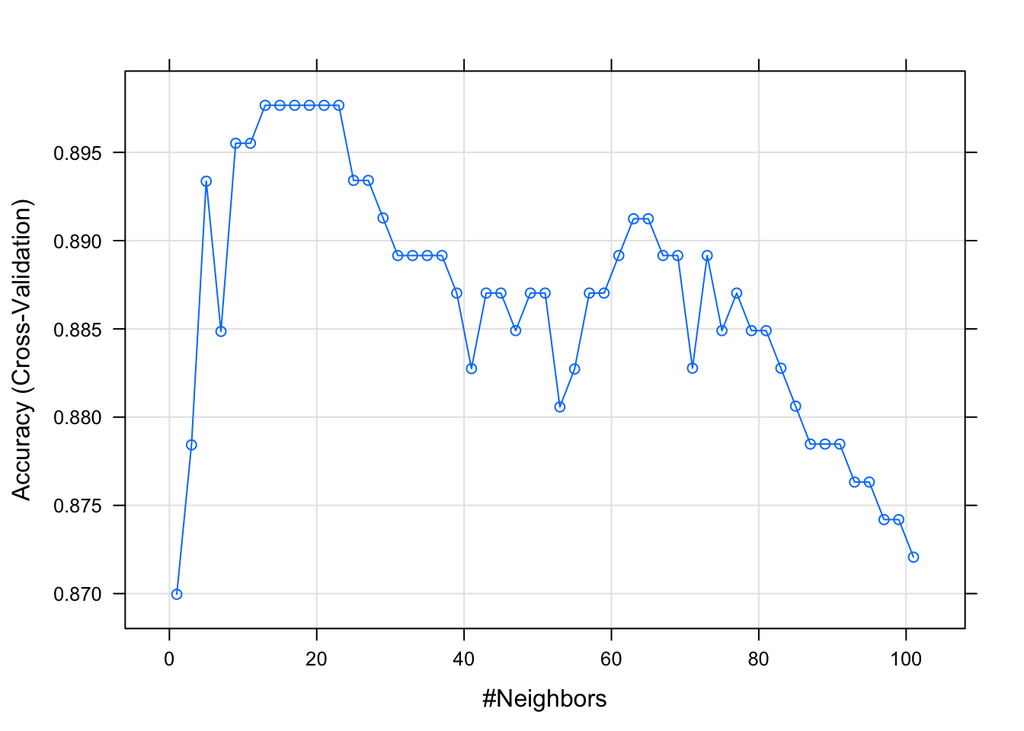

```r
plot(wisc_knn)
```

# Exercise 2 (More Tuning KNN with `caret`)

**[6 points]** Train a KNN model using all available predictors, predictors scaled to have mean 0 and variance 1, 5-fold cross-validation, and a well chosen value of the tuning parameter. Consider $k = 1, 3, 5, 7, \ldots, 101$. Store the tuned model fit to the training data for later use. Plot the cross-validated accuracies as a function of the tuning parameter.

**Solution:**

```r
# setup knn tuning
knn_control    = trainControl(method = "cv", number = 5)
knn_preprocess = c("center", "scale")
knn_tuning     = expand.grid(k = seq(1, 101, by = 2))

# training and tune knn model
set.seed(1337)
wisc_knn_scaled = train(class ~ ., data = wisc_trn,  method = "knn",
                        trControl  = knn_control,
                        preProcess = knn_preprocess,
                        tuneGrid   = knn_tuning)
```

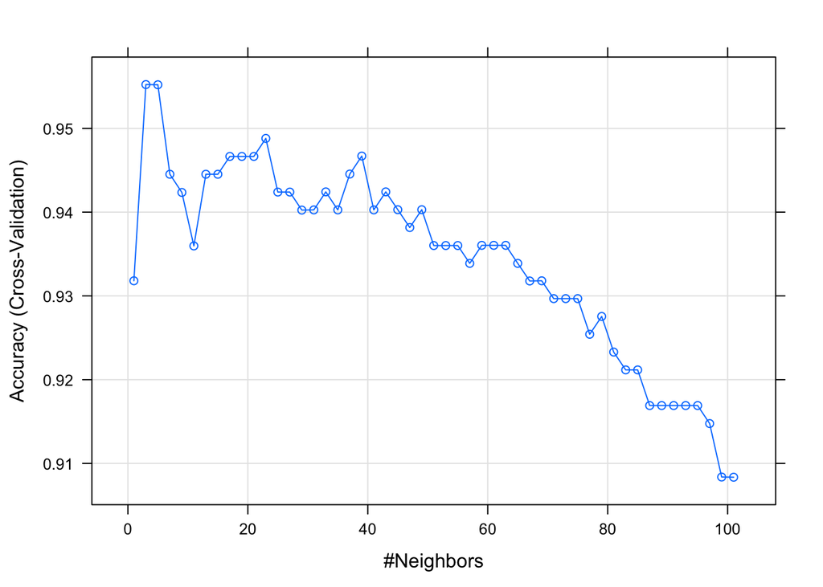

```r
plot(wisc_knn_scaled)
```

# Exercise 3 (Random Forest?)

**[6 points]** Now that we’ve introduced `caret`, it becomes extremely easy to try different statistical learning methods. Train a random forest using all available predictors, **no data preprocessing**, 5-fold cross-validation, and well a chosen value of the tuning parameter. Using `caret` to perform the tuning, there is only a single tuning parameter, `mtry`. Consider `mtry` values between 1 and 10. Store the tuned model fit to the training data for later use. Report the cross-validated accuracies as a function of the tuning parameter using a well formatted table.

**Solution:**

```r
# setup rf tuning
rf_control = trainControl(method = "cv", number = 5)
rf_tuning = expand.grid(mtry = c(1:10))


# training and tune knn model
set.seed(1337)
wisc_rf = train(class ~ ., data = wisc_trn,  method = "rf",
                trControl = rf_control,
                tuneGrid = rf_tuning)
```

```r
knitr::kable(wisc_rf$results, digits = 3)
```

| mtry | Accuracy | Kappa | AccuracySD | KappaSD |
| --- | --- | --- | --- | --- |
| 1 | 0.940 | 0.871 | 0.021 | 0.046 |
| 2 | 0.947 | 0.885 | 0.026 | 0.058 |
| 3 | 0.940 | 0.872 | 0.025 | 0.054 |
| 4 | 0.949 | 0.890 | 0.023 | 0.051 |
| 5 | 0.940 | 0.872 | 0.024 | 0.052 |
| 6 | 0.940 | 0.872 | 0.024 | 0.051 |
| 7 | 0.938 | 0.867 | 0.022 | 0.046 |
| 8 | 0.942 | 0.876 | 0.028 | 0.058 |
| 9 | 0.940 | 0.872 | 0.036 | 0.075 |
| 10 | 0.938 | 0.867 | 0.033 | 0.069 |

# Exercise 4 (Concept Checks)

**[1 point each]** Answer the following questions based on your results from the three exercises. Format your answer to this exercise as a table with one column indicating the part, and the other column for your answer. See the `rmarkdown` source for a template of this table.

**(a)** What value of $k$ is chosen for KNN without predictor scaling?

**(b)** What is the cross-validated accuracy for KNN without predictor scaling?

**(c)** What is the test accuracy for KNN without predictor scaling?

**(d)** What value of $k$ is chosen for KNN **with** predictor scaling?

**(e)** What is the cross-validated accuracy for KNN **with** predictor scaling?

**(f)** What is the test accuracy for KNN **with** predictor scaling?

**(g)** Do you think that KNN is performing better with or without predictor scaling?

**(h)** What value of `mtry` is chosen for the random forest?

**(i)** Using the random forest, what is the (estimated) probability that the 10th observation of the test data is a cancerous tumor?

**(j)** Using the random forest, what is the (test) sensitivity?

**(k)** Using the random forest, what is the (test) specificity?

**(l)** Based on these results, is the random forest or KNN model performing better?

```r
calc_acc = function(actual, predicted) {
  mean(actual == predicted)
}
```

```r
get_best_result = function(caret_fit) {
  best = which(rownames(caret_fit$results) == rownames(caret_fit$bestTune))
  best_result = caret_fit$results[best, ]
  rownames(best_result) = NULL
  best_result
}
```

```r
a = wisc_knn$bestTune$k
b = get_best_result(wisc_knn)$Accuracy
c = calc_acc(actual = wisc_tst$class, predicted = predict(wisc_knn, wisc_tst))
d = wisc_knn_scaled$bestTune$k
e = get_best_result(wisc_knn_scaled)$Accuracy
f = calc_acc(actual = wisc_tst$class, predicted = predict(wisc_knn_scaled, wisc_tst))
g = "With scaling."
h = wisc_rf$bestTune$mtry
i = predict(wisc_rf, wisc_tst[10,], type = "prob")$M

wisc_rf_conmat = confusionMatrix(table(predicted = predict(wisc_rf, wisc_tst),
                                       actual = wisc_tst$class),
                                 positive = "M")

j = wisc_rf_conmat$byClass["Sensitivity"]
k = wisc_rf_conmat$byClass["Specificity"]
l = ifelse(calc_acc(actual = wisc_tst$class,
                    predicted = predict(wisc_rf, wisc_tst)) >
           calc_acc(actual = wisc_tst$class,
                    predicted = predict(wisc_knn_scaled, wisc_tst)),
           yes = "Random Forest",
           no = "KNN")

results = data.frame(
  part = LETTERS[1:12],
  answer = c(a,b,c,d,e,f,g,h,i,j,k,l)
)

knitr::kable(results)
```

| part | answer |
| --- | --- |
| A | 23 |
| B | 0.897666437886067 |
| C | 0.86 |
| D | 3 |
| E | 0.955227636696408 |
| F | 0.88 |
| G | With scaling. |
| H | 4 |
| I | 0.04 |
| J | 0.875 |
| K | 0.966666666666667 |
| L | Random Forest |